# Tainted Trends

Pre-Registration

Authors

Affiliations

Hauke Roggenkamp

Institute of Behavioral Science and Technology, University of St. Gallen

Faculty of Economics & Social Sciences, Helmut-Schmidt-University

Christian Hildebrand

Institute of Behavioral Science and Technology, University of St. Gallen

Published

November 10, 2023

This document briefly describes the motivation, the design, the processing of the eventual data as well as the analyses of an experiment we plan to run.

# Motivation

In today’s hyperconnected world, brands are co-created by a variety of stakeholders (Swaminathan et al. 2020). We study exogenously inflicted brand dilution caused by stakeholders who *hijack* brand experiences in social media (Grier et al. 2010). Specifically, we investigate the contaminating effect (Whitler, Besharat, and Kashmiri 2021) of stakeholders who append their (from a brand’s perspective) unfavorable content to a branded hashtag.

# Install Packages

We install the following packages using the `groundhog` package manager to increase computational reproducibility.

```r
if (!requireNamespace("groundhog", quietly = TRUE)) {
    install.packages("groundhog")
    library("groundhog")
}

pkgs <- c("magrittr", "data.table", "knitr", "stringr", "jsonlite",
          "ggplot2", "patchwork",
          "stargazer")

groundhog::groundhog.library(pkg = pkgs,
                             date = "2023-09-25")

rm(pkgs)
```

# Preprocessing

## Read Data

```r
raw <- data.table::fread(file = "../data/testing/all_apps_wide-2023-11-09.csv")
```

## Select Data

```r
cols <- str_detect(string = names(raw),
                   pattern = "participant.label|participant.code|liked_item|reply_to_item|favorable|sequence|viewport")

data <- raw[, ..cols]
```

## Rename Data

```r
names(data) %>%
  str_replace_all(pattern = ".*player\\.", replacement = "") %>%
  str_replace_all(pattern = "\\.", replacement = "_") %>%
  str_to_lower() %>%
  setnames(x = data)
```

## Number or Fraction of Unfavorable Tweets

```r
feed_composition <- data[,
                         .(favorable_count = favorable_feed %>%
                             strsplit(split = ',') %>%
                             unlist() %>%
                             as.numeric() %>%
                             sum(na.rm = TRUE),
                           total_count = favorable_feed %>%
                             strsplit(split = ',') %>%
                             unlist() %>%
                             length()),
                         by = participant_code]

feed_composition[, fraction_unfavorable := ((1 - favorable_count / total_count)*100)]
```

## Treatment Info by Tweet

```r
condition <- data[,
                  .(favorable = favorable_feed %>%
                      strsplit(split = ',') %>%
                      unlist() %>%
                      str_replace(pattern = ' ',
                                  replacement = '') %>%
                      as.character() %>%
                      as.numeric() %>%
                      as.logical()),
                  by = participant_code]

condition[, displayed_sequence := 1:.N, by = participant_code]
```

## Item Sequence

```r
sequence_list <- lapply(seq(nrow(data)), function(i) {
  participant_code <- data[i, participant_code]
  sequence <- data[i, sequence]
  tmp <- data.table(participant_code = rep(participant_code,
                                           length(unlist(strsplit(sequence, ", ")))),
                    tweet = unlist(base::strsplit(x = sequence,
                                                  split = ", ")) %>%
                      as.integer())
  tmp[, displayed_sequence := 1:.N]
  return(tmp)
})

# Combine the list of data.tables into one data.table
display <- rbindlist(sequence_list)

rm(list = c('sequence_list', 'tmp'))
```

## Scroll Sequence

Because people may scroll back and forth, this sequence may be longer than the number of tweets, simply because some tweets may occur several times in that scroll sequence.

```r
scroll <- data[,
               .(participant_code,
                 tweet = scroll_sequence %>%
                   strsplit(split = '-') %>%
                   unlist() %>%
                   str_replace_all(pattern = 'i',
                                   replacement = '')),
               by = participant_code][!(tweet == shift(tweet, type = "lead")),
                                      by = participant_code][,
                                                             scroll_sequence := 1:.N,
                                                             by = participant_code]



data[1, .(participant_code,
        item = scroll_sequence %>%
          strsplit(split = '-') %>%
          unlist() %>%
          str_replace_all(pattern = 'i', replacement = ''))][!(item == shift(item, type = "lead")), ][, scroll_sequence := 1:.N]
```

## Viewport

```r
viewport <- data[,
                 viewport_data %>%
                     str_replace_all(pattern = '""',
                                     replacement = '"') %>%
                     fromJSON,
                 by = participant_code][!is.na(doc_id)]

# sum of durations by tweet (in case someone scrolled back and forth)
viewport <- viewport[,
                     .(seconds_in_viewport = sum(duration,
                                                 na.rm = TRUE)),
                     by = c('participant_code', 'doc_id')]


# rename
setnames(x = viewport,
         old = 'doc_id',
         new = 'tweet')
```

## Reactions

```r
# make sure each and every reply column is a string
sdcols <- names(data) %>%
  str_subset(pattern = "reply_to_item")
data[,
     paste0(sdcols) := lapply(.SD, as.character),
     .SDcols = sdcols]

# melt data
reactions <- data.table::melt(data = data,
                              id.vars = c('participant_code', 'participant_label'),
                              measure.vars = patterns('liked_item_', 'reply_to_item'),
                              variable.name = 'tweet',
                              value.name = c('likes', 'replies'))

# make tweet identifier numeric for compatibility reasons.
reactions[, tweet := as.numeric(as.character(tweet))]
```

## Self-Reports

```r
# select
cols <- str_detect(string = names(raw),
                   pattern = "participant\\.code|trust|usability|KFC|meatless|\\.age|gender|completed|perception|food|frequency|education|genAI")

self_reports <- raw[, ..cols]

# rename
names(self_reports) %>%
  str_replace_all(pattern = ".*player\\.", replacement = "") %>%
  str_replace_all(pattern = "\\.", replacement = "_") %>%
  str_to_lower() %>%
  setnames(x = self_reports)
```

```r
# calculate simple indices

self_reports[, trust := (trust_1 + trust_2 + trust_3 + trust_4)/4]
self_reports[, usability := (usability_1 + usability_2 + usability_3)/3]

# transform gender variable
self_reports[, female := 1]
self_reports[gender != 1, female := 0]

# ... and meatless
self_reports[, vegetarian := 0]
self_reports[meatless == "Yes", vegetarian := 1]
```

## Merge

Note that the last item displayed never leaves the viewport which is why we do not measure the duration it is displayed.

```r
# merge 1: displayed tweets with condition info
long <- display[condition, on = .(participant_code, displayed_sequence)]

# merge 2: long with viewport data (full join)
long <- rbind(
  fill = TRUE,
  long[viewport, on = .(participant_code, tweet)],  # join
  long[!viewport, on = .(participant_code, tweet)]  # anti-join
)

# merge 2: long with reactions (left join)
long <- long[reactions, on = .(participant_code, tweet)]

# merge 3: long with reactions (left join)
long <- long[feed_composition, on = .(participant_code)]

# merge 4: long with self-reports
long <- long[self_reports, on = .(participant_code)]


# remove items that haven't been displayed
tweets <- long[!is.na(displayed_sequence)]

# order
setorder(x = tweets, participant_code, displayed_sequence)
```

## Individual Level Data

```r
individuals <- tweets[, -(2:8)] %>% unique()
```

## Write Data

```r
fwrite(x = tweets,
       file = '../data/processed/tweet_level_data.csv')
fwrite(x = individuals,
       file = '../data/processed/tweet_level_data.csv')
```

## Clean up

Lastly, we clean the global environment.

```r
objects <- c(ls(), "objects", "objects_to_keep", "objects_to_remove")
objects_to_keep <- c("raw", "tweets", "individuals")
objects_to_remove <- setdiff(objects, objects_to_keep)
rm(list = objects_to_remove)
```

# Exclusion

We exclude participants who self-reported that they used a generative AI to answer our questions. In addition, we only focus on participants who completed the survey.

```r
individuals <- individuals[completed_survey == TRUE & genai == "No"]
tweets <- tweets[participant_code %in% individuals[, participant_code %>% unique()]]
```

# Balance

| fraction_unfavorable | N | Age | Female |
| --- | --- | --- | --- |
| 100 | 2 | 44.00000 | 0.50 |
| 0 | 4 | 41.75000 | 0.25 |
| 80 | 2 | 33.00000 | 1.00 |
| 20 | 3 | 32.66667 | 0.00 |
| 40 | 1 | 44.00000 | 1.00 |
| 60 | 2 | 47.00000 | 0.00 |

# Analyses

Summary Statistics for Trust Measure by Feed Composition

| fraction_unfavorable | mean_trust | sd_trust | count |
| --- | --- | --- | --- |
| 0 | 6.250 | 0.3535534 | 4 |
| 20 | 4.250 | 2.3848480 | 3 |
| 40 | 3.000 | NA | 1 |
| 60 | 2.000 | 0.0000000 | 2 |
| 80 | 1.875 | 0.1767767 | 2 |
| 100 | 1.750 | 0.3535534 | 2 |

Level of Trust by Feed Composition

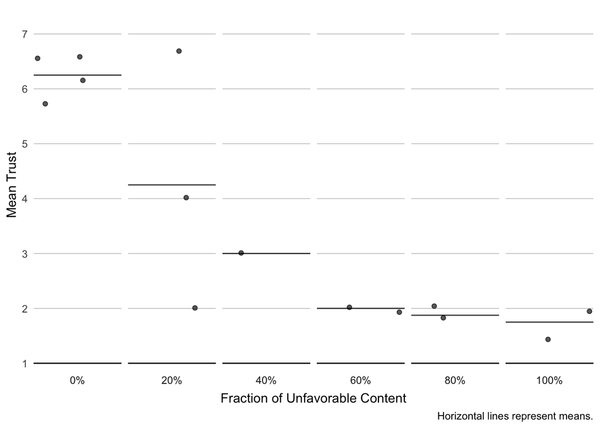

|  | *Dependent variable:* |  |  |  |  |  |
| --- | --- | --- | --- | --- | --- | --- |
|  | trust |  |  | kfc_brand |  |  |
|  | (1) | (2) | (3) | (4) | (5) | (6) |
| fraction_unfavorable | -0.047*** | -0.045*** | 0.009 | -0.025*** | -0.023*** | -0.060* |
|  | (0.009) | (0.010) | (0.044) | (0.007) | (0.007) | (0.029) |
| vegetarian |  | 1.598 | 3.592 |  | -1.055 | -1.526 |
|  |  | (1.586) | (2.513) |  | (1.108) | (1.684) |
| kfc_food |  | 0.217 | 0.606 |  | 0.056 | -0.156 |
|  |  | (0.351) | (0.472) |  | (0.245) | (0.316) |
| fraction_unfavorable:vegetarian |  |  | -0.048 |  |  | 0.021 |
|  |  |  | (0.040) |  |  | (0.027) |
| fraction_unfavorable:kfc_food |  |  | -0.011 |  |  | 0.009 |
|  |  |  | (0.009) |  |  | (0.006) |
| Constant | 5.677*** | 4.439** | 2.302 | 4.836*** | 4.669*** | 5.682** |
|  | (0.484) | (1.931) | (2.627) | (0.374) | (1.349) | (1.760) |
| Observations | 14 | 14 | 14 | 14 | 14 | 14 |
| R<sup>2</sup> | 0.710 | 0.739 | 0.783 | 0.539 | 0.661 | 0.741 |
| Adjusted R<sup>2</sup> | 0.686 | 0.660 | 0.647 | 0.501 | 0.560 | 0.579 |
| Residual Std. Error | 1.198 (df = 12) | 1.245 (df = 10) | 1.269 (df = 8) | 0.927 (df = 12) | 0.870 (df = 10) | 0.851 (df = 8) |
| F Statistic | 29.345*** (df = 1; 12) | 9.427*** (df = 3; 10) | 5.767** (df = 5; 8) | 14.044*** (df = 1; 12) | 6.507** (df = 3; 10) | 4.580** (df = 5; 8) |
| *Note:* | *p<0.1; **p<0.05;*** p<0.01 |  |  |  |  |  |

# Visualizations

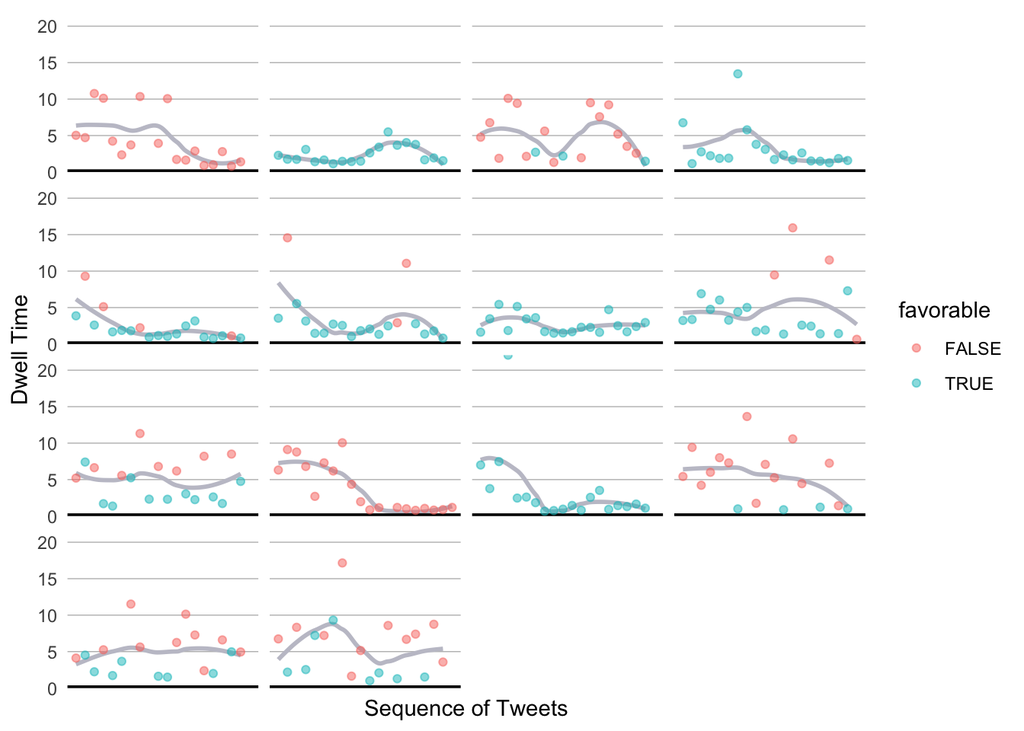

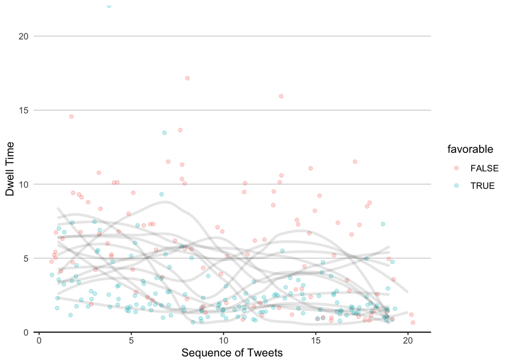

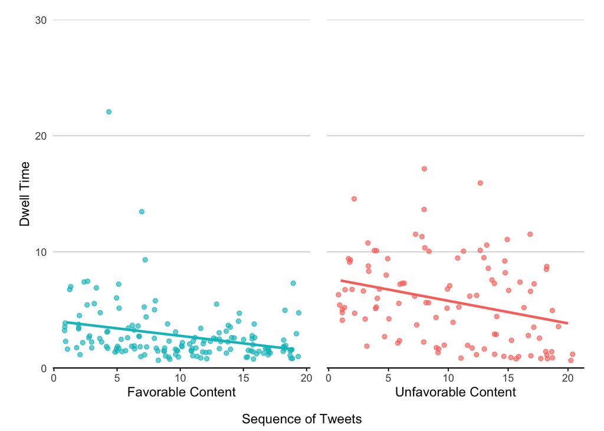

## References

Grier, Chris, Kurt Thomas, Vern Paxson, and Michael Zhang. 2010. “@Spam: The Underground on 140 Characters or Less.” In *Proceedings of the 17th ACM Conference on Computer and Communications Security*, 27–37. CCS ’10. New York, NY, USA: Association for Computing Machinery. https://doi.org/10.1145/1866307.1866311.

Swaminathan, Vanitha, Alina Sorescu, Jan-Benedict E. M. Steenkamp, Thomas Clayton Gibson O’Guinn, and Bernd Schmitt. 2020. “Branding in a Hyperconnected World: Refocusing Theories and Rethinking Boundaries.” *Journal of Marketing* 84 (2): 24–46. https://doi.org/10.1177/0022242919899905.

Whitler, Kimberly A., Ali Besharat, and Saim Kashmiri. 2021. “Exogenous Brand Crises: Brand Infection and Contamination.” *Marketing Letters* 32 (1): 129–33. https://doi.org/10.1007/s11002-020-09554-4.